# EDA of the Calls Volume

Valerie Blanch

2022-12-29

**Call volume EDA: Analyze the calls volume for the :**

- Longitudinal analysis of calls types and volume.
- Calls types by area (understand top 3 or 5 services overall and for each area)

```r
#loading packages

library(tidyverse)
library(readxl)
library(stringr)
library(lubridate)
library(knitr)
library(gridExtra)

#loading datasets

interactions_2020 <- read_csv('uwwi_dataset_interactions_2020.csv')
interactions_2021 <- read_csv('uwwi_dataset_interactions_2021.csv')
interactions_2022 <- read_csv('uwwi_dataset_interactions_2022.csv')

module_2020 <- read_csv('uwwi_dataset_interactions_2020_ReferralsModule.csv')
module_2021 <- read_csv('uwwi_dataset_interactions_2021_ReferralsModule.csv')
module_2022 <- read_csv('uwwi_dataset_interactions_2022_ReferralsModule.csv')

clients <- read_csv('uwwi_dataset_clients_v2.csv')

#concatenating datasets

interaction <- rbind(interactions_2020, interactions_2021, interactions_2022)

referrals <- rbind(module_2020, module_2021, module_2022)
```

**Quick summary of the datasets**

- The three following datasets were needed for this analysis:
1. The “interaction” dataset is a regrouping of three datasets provided by UWWi. It contains the data (40 variables) of every call received by the 211 line for the years 2020, 2021 and 2022. Each observation corresponds to the ID of one call. This dataset contains 4051 unique client IDS for 32,742 calls, indicating a important number of returning clients.

```r
#inspecting the dimension of the "interaction" dataset

dim(interaction)
```

```
## [1] 32742    40
```

```r
#verifying if there is any duplicated call

length(unique(interaction$Interaction_Id)) == nrow(interaction)
```

```
## [1] TRUE
```

```r
#computing the number of unique clients

length(unique(interaction$Client_Id))
```

```
## [1] 4051
```

2. The “referrals” dataset is a regrouping of three datasets extracted by DataKind volunteers from the “interaction” raw datasets. It corresponds to a single column separated into 29 variables, regarding which institutions the clients have been referred to. The number of rows of the “referrals” dataset is higher than the number of rows in the “interaction” dataset because one call can lead to multiple referrals (food, shelter etc.).

```r
#inspecting the dimensions of the "referrals" dataset

dim(referrals)
```

```
## [1] 47587    29
```

```r
#inspecting the number of unique calls (duplicates?)

length(unique(referrals$Interaction_Id)) == nrow(interaction)
```

```
## [1] TRUE
```

```r
#computing the number of unique clients (duplicates?)

length(unique(referrals$Client_Id)) == length(unique(interaction$Client_Id))
```

```
## [1] TRUE
```

3. The “clients” dataset contains the anonymized personal data of the clients. There are 830,450 unique client ids recorded in the database, and general information on the location and demographics of the clients in 13 different variables.

```r
#printing the dimensions of the "clients" dataset

dim(clients)
```

```
## [1] 830450     13
```

```r
#verifying if there is any duplicated client id

length(unique(clients$Client_Id)) == nrow(clients)
```

```
## [1] TRUE
```

**1.Longitudinal analysis of calls types and volume**

- The term “calls types” refers to the client needs. It can be housing, food, mental health issues etc. Depending on the needs of the client who calls 211, the UWWi agent provides corresponding resources (institutions, organisations, non-profits etc.) recorded in the “referrals” dataset.
- First, we will inspect the volume of calls from a longitudinal perspective, and try to evaluate potential trends.
- Then, which type of calls are the most prevalent.

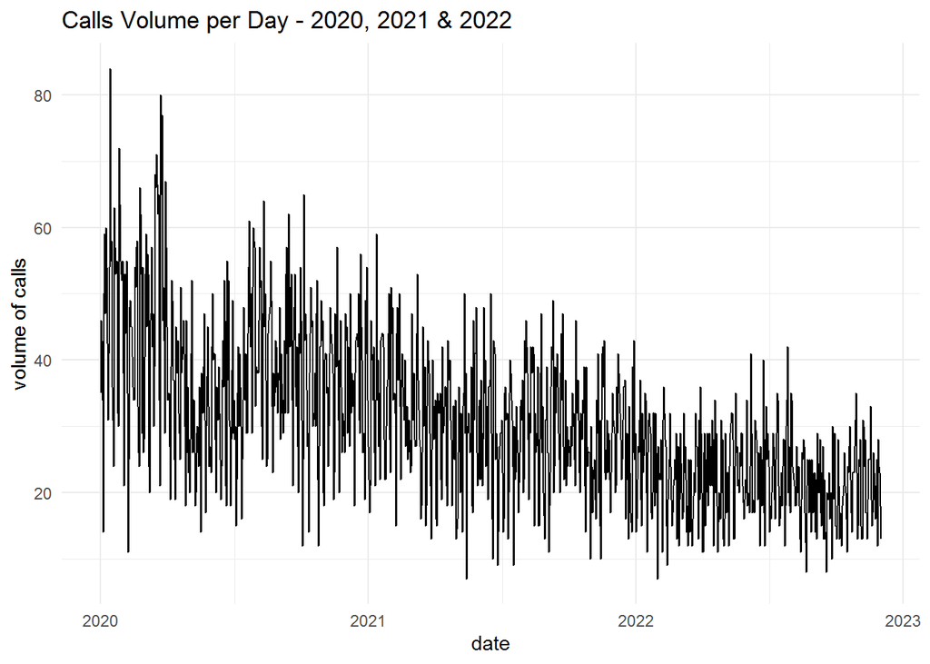

```r
#separating the timestamp column
#one colunm for the date and one for the hour

interaction$hour <- interaction$Interaction_CreateStamp

interaction$Interaction_CreateStamp <- as.Date(interaction$Interaction_CreateStamp)

interaction$hour <- gsub('....-..-..', '', interaction$hour)
interaction$hour <- gsub(' ', '', interaction$hour)

#ordering the "interaction" dataset by timestamp

interaction <- interaction[order(interaction$Interaction_CreateStamp),]

#calculating number of calls per day

table_1 <- as.data.frame(table(interaction$Interaction_CreateStamp))

#drawing a time series plot of number of calls per day for the whole time-period

plot_1 <- ggplot(table_1, aes(x = as.Date(Var1), y = Freq)) +
  geom_line()+
  labs(x = "date", y = "volume of calls")+
  ggtitle('Calls Volume per Day - 2020, 2021 & 2022')+
  theme_minimal()

plot_1
```

- The plot above shows that there is a decreasing trend for the daily volume of calls for the years 2020, 2021 and 2022, with great variability on a day to day basis.

```r
#printing summary stats of the daily volume of calls

summary(table_1$Freq)
```

```
##    Min. 1st Qu.  Median    Mean 3rd Qu.    Max.
##    7.00   22.00   29.00   30.71   38.00   84.00
```

- The smallest number of calls received in one day is 7 (corresponding to the 2021-05-15 and the 2022-01-30). The biggest number of calls received in one day is 84 (on the 2020-01-14). On average, the 211 line receives 29 calls per day (median).

**Calls Volume per Month**

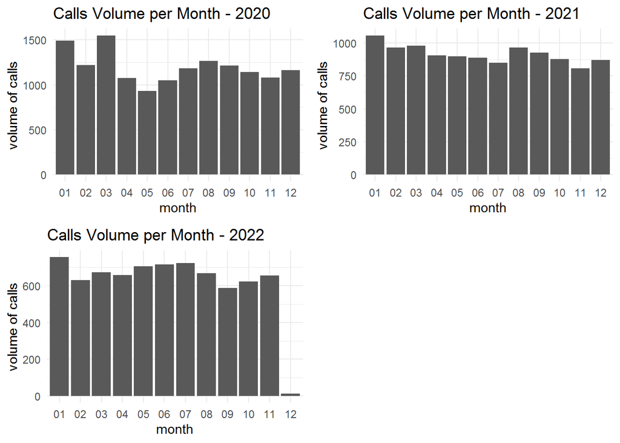

```r
#creating a new variable which only contains the month of the call received

interaction$month <- interaction$Interaction_CreateStamp

interaction$month <- str_sub(interaction$month, start=6, end=-4)

#converting the month variable into ordinal factor

interaction$month <- factor(interaction$month, order = TRUE,
    levels = c("01", "02", "03", '04', '05', '06', '07',
               '08', '09', '10', '11', '12'))

#separating occurrence by month and by year

table_2 <- as.data.frame(table(interaction$month[1:14357]))
table_3 <- as.data.frame(table(interaction$month[14358:25344]))
table_4 <- as.data.frame(table(interaction$month[25345:32742]))

#drawing the plot of the volume of calls per month for 2020

plot_2 <- ggplot(table_2, aes(x = Var1, y = Freq)) +
  geom_col()+
  labs(x = "month", y = "volume of calls")+
  ggtitle('Calls Volume per Month - 2020')+
  theme_minimal()

#drawing the plot of the volume of calls per month for 2021

plot_3 <- ggplot(table_3, aes(x = Var1, y = Freq)) +
  geom_col()+
  labs(x = "month", y = "volume of calls")+
  ggtitle('Calls Volume per Month - 2021')+
  theme_minimal()

#drawing the plot of the volume of calls per month for 2022

plot_4 <- ggplot(table_4, aes(x = Var1, y = Freq)) +
  geom_col()+
  labs(x = "month", y = "volume of calls")+
  ggtitle('Calls Volume per Month - 2022')+
  theme_minimal()

grid.arrange(plot_2, plot_3, plot_4, ncol=2)
```

- For the year 2020, the busiest months are January and March, the latter exceeding 1,500 calls.
- For 2021, January is the busiest month as well.
- Idem for 2022.
- It is interesting to note that the bar plot for 2020 shows abnormally high volume of 211 calls, most probably linked to Covid-19 news cycle (beginning of the pandemic in January worldwide, then in Wisconsin in March, along with cancellations of public events and finally a general lockdown on the 23th - Source: https://eu.jsonline.com/in-depth/news/local/milwaukee/2021/03/11/timeline-how-covid-19-has-played-out-wisconsin/4522813001/).
- However, since January sees a particularly high volume of calls every year, the volume of calls could be linked to weather as well.
- December of 2022 has barely any call, because at the time of the study, they haven’t been recorded yet.

**Calls Volume per Weekday**

```r
Sys.setlocale("LC_TIME","C")
```

```
## [1] "C"
```

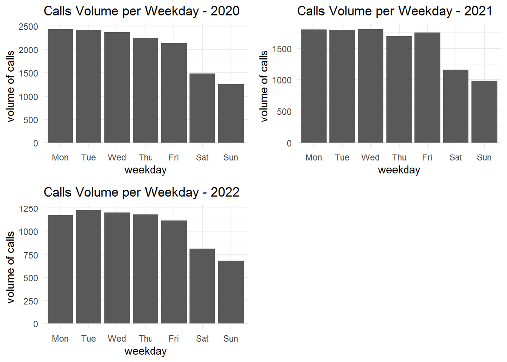

```r
#creating a new column containing the days of the week

interaction$day <- wday(interaction$Interaction_CreateStamp,label=TRUE,
                        week_start=1)


#creating frequency tables for the volume of calls per weekday
#one per year

table_5 <- as.data.frame(table(interaction$day[1:14357]))
table_6 <- as.data.frame(table(interaction$day[14358:25344]))
table_7 <- as.data.frame(table(interaction$day[25345:32742]))

#drawing the plot of the volume of calls per weekday for 2020

plot_5 <- ggplot(table_5, aes(x = Var1, y = Freq)) +
  geom_col()+
  labs(x = "weekday", y = "volume of calls")+
  ggtitle('Calls Volume per Weekday - 2020')+
  theme_minimal()

#drawing a bar plot of the volume of calls per weekday - 2021

plot_6 <- ggplot(table_6, aes(x = Var1, y = Freq)) +
  geom_col()+
  labs(x = "weekday", y = "volume of calls")+
  ggtitle('Calls Volume per Weekday - 2021')+
  theme_minimal()

#plotting the volume of calls per weekday - 2022

plot_7 <- ggplot(table_7, aes(x = Var1, y = Freq)) +
  geom_col()+
  labs(x = "weekday", y = "volume of calls")+
  ggtitle('Calls Volume per Weekday - 2022')+
  theme_minimal()

grid.arrange(plot_5, plot_6, plot_7, ncol=2)
```

- According to the bar plots above, it seems the volume of calls is significantly lower on the weekend, for 2020, 2021 and 2022. Sunday is, for the three years, the least busy day of the week for thee 211 line.

**Calls Volume per Hour**

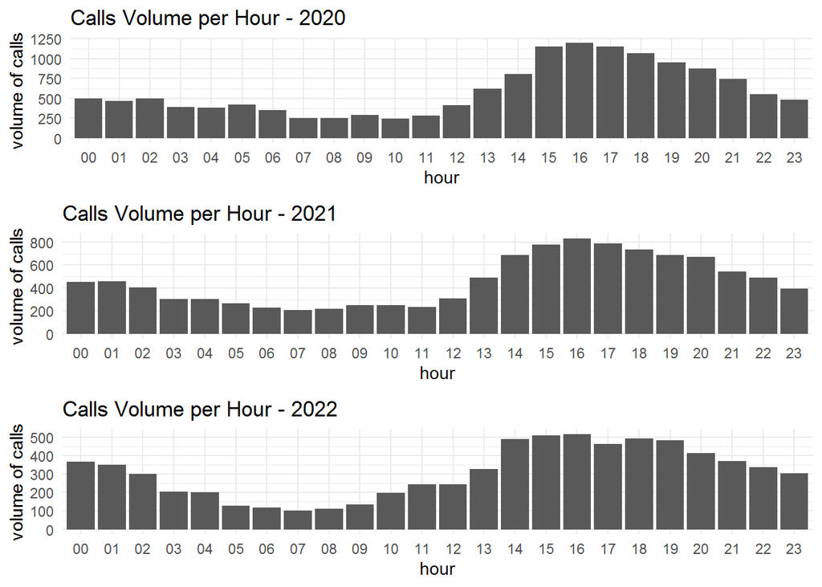

```r
#cleaning the hour column

interaction$hour <- str_sub(interaction$hour, end=-7)

#creating frequency tables for call volume per hour

table_8 <- as.data.frame(table(interaction$hour[1:14357]))
table_9 <- as.data.frame(table(interaction$hour[14358:25344]))
table_10 <- as.data.frame(table(interaction$hour[25345:32742]))

#drawing the plot of the volume of calls per weekday for 2020

plot_8 <- ggplot(table_8, aes(x = Var1, y = Freq)) +
  geom_col()+
  labs(x = "hour", y = "volume of calls")+
  ggtitle('Calls Volume per Hour - 2020')+
  theme_minimal()

#drawing the plot of the volume of calls per weekday for 2021

plot_9 <- ggplot(table_9, aes(x = Var1, y = Freq)) +
  geom_col()+
  labs(x = "hour", y = "volume of calls")+
  ggtitle('Calls Volume per Hour - 2021')+
  theme_minimal()

#drawing the plot of the volume of calls per weekday for 2022

plot_10 <- ggplot(table_10, aes(x = Var1, y = Freq)) +
  geom_col()+
  labs(x = "hour", y = "volume of calls")+
  ggtitle('Calls Volume per Hour - 2022')+
  theme_minimal()

grid.arrange(plot_8, plot_9, plot_10)
```

- The bar plots representing the volume of calls per hour are very similar for the three years 2020, 2021 and 2022. We can observe a peak in the afternoon around 4pm, while early morning - around 7am - is the least busy hour.

**Call types:**

**EDA of the “referrals” dataset**

```r
#computing summary statistics - number of referrals vs number of calls

ref_stats <- as.data.frame(table(referrals$Interaction_Id))

summary(ref_stats$Freq)
```

```
##    Min. 1st Qu.  Median    Mean 3rd Qu.    Max.
##   1.000   1.000   1.000   1.453   1.000  15.000
```

- Computing the summary statistics of the volume of referrals in relation to the number of calls, it seems that only a minority of calls triggers multiple referrals, and most of the calls (75% at least) only has one problematic attached to them. The mean is higher than one (1.45 referrals per call) because it is highly influenced by the maximum values/outliers (max number of referrals for one call = 15 referrals).

```r
#finding the exact number of calls with number of referrals > 1

sum(ref_stats$Freq > 1)
```

```
## [1] 7559
```

- 7,559 calls out of 32,742 lead to more than one referral.

```r
#computing the proportion of calls with referrals == 1

1 - (7559/32742)
```

```
## [1] 0.7691344
```

- As assumed above, we obtain around 77% of calls with only one referral.

```r
#looking for missing values in the code variable

referrals$Taxonomy_Name <- ifelse(referrals$Taxonomy_Name == 'None',
                                  NA, referrals$Taxonomy_Name)

sum(is.na(referrals$Taxonomy_Name))
```

```
## [1] 10471
```

- All calls recorded in the interaction dataset are present in the referrals dataset. However, there are 10,471 missing values in the ‘Taxonomy_Name’ variable.

```r
#printing the top 5 values in the "Taxonomy_Name" variable

table_top5 <- as.data.frame(sort(table(referrals$Taxonomy_Name),
                               decreasing = T)[1:5])

table_top <- as.data.frame(sort(proportions(table(referrals$Taxonomy_Name))*100,
                               decreasing = T)[1:5])

table_top5 <- left_join(table_top5, table_top, by='Var1')

colnames(table_top5) <- c('Most_Frequent_Referrals', 'Volumes', 'Percentages')

kable(table_top5)
```

| Most_Frequent_Referrals | Volumes | Percentages |
| --- | --- | --- |
| ‘Talklines/Warmlines’ | 5545 | 14.939649 |
| ‘Mental Health Crisis Lines’ | 4878 | 13.142580 |
| ‘Food Pantries’ | 2781 | 7.492725 |
| ‘Community Shelters’ | 1759 | 4.739196 |
| ‘211 Systems’ | 887 | 2.389805 |

- Mental health issues dominate the total volume of referrals, followed by food and housing problems. The percentages are low because of the high number of missing values.
- These call types can be analysed further by plotting their evolution over time, while using their proportion of the total number of referrals.

**Talklines/Warmlines**

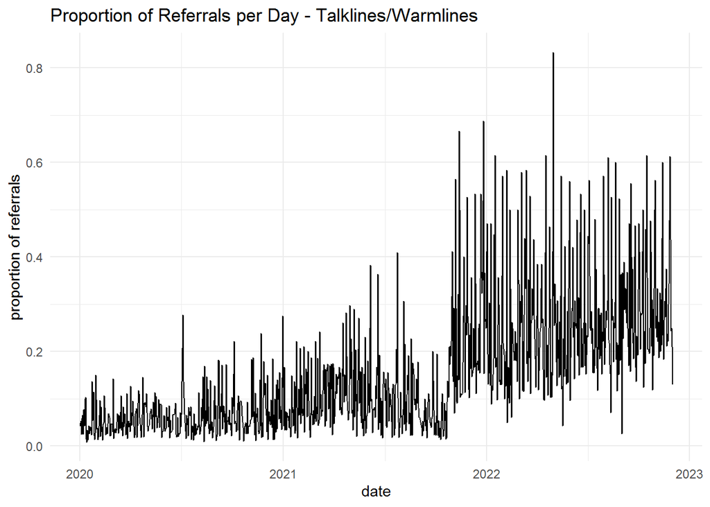

```r
#adding date and time variables to the 'referrals' dataset

referrals <- left_join(referrals,
                       interaction[,c(2, 4, 41, 42, 43)], by='Interaction_Id')

#subsetting talklines/warmlines calls

talklines <- referrals[referrals$Taxonomy_Name=="'Talklines/Warmlines'",]

#calculating talklines/warmlines referral volume per day

table_12 <- as.data.frame(table(talklines$Interaction_CreateStamp))

#calculating total volume of referrals per day

table_total <- as.data.frame(table(referrals$Interaction_CreateStamp))

#computing proportion vs total referrals

table_12 <- left_join(table_12, table_total, by='Var1')

table_12$Prop <- table_12$Freq.x/table_12$Freq.y

#drawing a time series plot of number of calls per day for the whole time-period

plot_12 <- ggplot(table_12, aes(x = as.Date(Var1), y = Prop)) +
  geom_line()+
  labs(x = "date", y = "proportion of referrals")+
  ggtitle('Proportion of Referrals per Day - Talklines/Warmlines')+
  theme_minimal()

plot_12
```

- The volume of referrals per day for the “Talklines/Warmlines” calls types seems to increase over time, with a strong growth at the end of 2021.

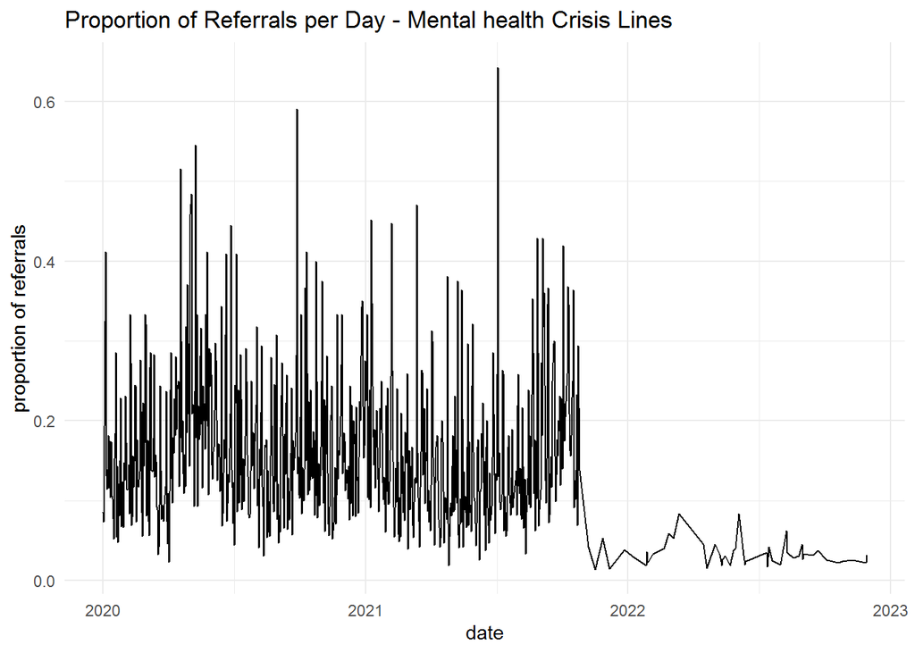

```r
#subsetting mental health crisis lines calls

mental_h <- referrals[referrals$Taxonomy_Name=="'Mental Health Crisis Lines'",]

#calculating referral volume per day

table_14 <- as.data.frame(table(mental_h$Interaction_CreateStamp))

#computing proportion vs total referrals

table_14 <- left_join(table_14, table_total, by='Var1')

table_14$Prop <- table_14$Freq.x/table_14$Freq.y

#drawing a time series plot of number of calls per day for the whole time-period

plot_14 <- ggplot(table_14, aes(x = as.Date(Var1), y = Prop)) +
  geom_line()+
  labs(x = "date", y = "proportion of referrals")+
  ggtitle('Proportion of Referrals per Day - Mental health Crisis Lines')+
  theme_minimal()

plot_14
```

- It seems like the “Mental Health Crisis Lines” Taxonomy code is not much used at the end of 2021 onward, to be replaced by the “Talklines/warmlines” code. Therefore, the two codes/names will be merged together, and the plot redrawn.

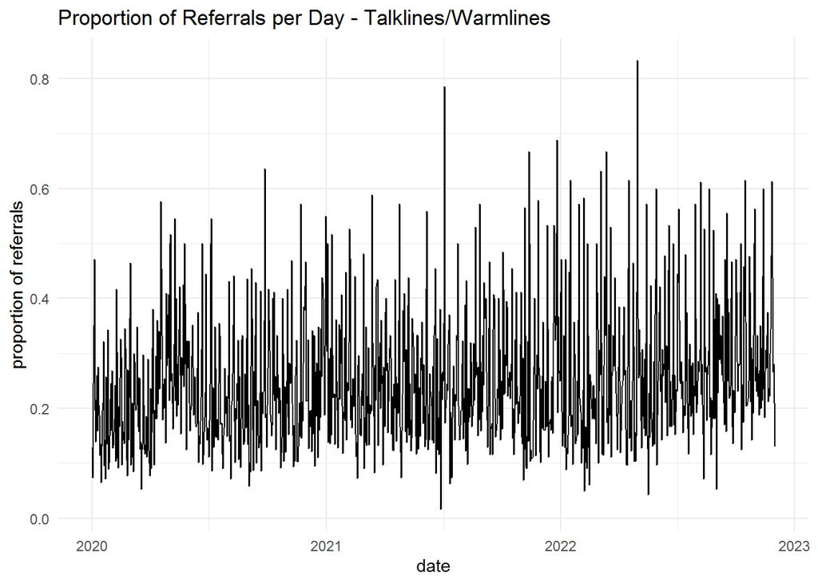

```r
#merging talkines/warmlines and mental health crisis lines calls together

referrals$Taxonomy_Name <- str_replace(referrals$Taxonomy_Name,
                                       "'Mental Health Crisis Lines'",
                                       "'Talklines/Warmlines'")

#redrawing the time series for talklines/Warmlines referral proportion

#subsetting talklines/warmlines calls

talklines <- referrals[referrals$Taxonomy_Name=="'Talklines/Warmlines'",]

#calculating talklines/warmlines referral volume per day

table_12 <- as.data.frame(table(talklines$Interaction_CreateStamp))

#computing proportion vs total referrals

table_12 <- left_join(table_12, table_total, by='Var1')

table_12$Prop <- table_12$Freq.x/table_12$Freq.y

#drawing a time series plot of number of calls per day for the whole time-period

plot_12 <- ggplot(table_12, aes(x = as.Date(Var1), y = Prop)) +
  geom_line()+
  labs(x = "date", y = "proportion of referrals")+
  ggtitle('Proportion of Referrals per Day - Talklines/Warmlines')+
  theme_minimal()

plot_12
```

```r
#extracting top 5 services again

#printing the top 5 values in the "Taxonomy_Name" variable

table_top5 <- as.data.frame(sort(table(referrals$Taxonomy_Name),
                               decreasing = T)[1:5])

table_top <- as.data.frame(sort(proportions(table(referrals$Taxonomy_Name))*100,
                               decreasing = T)[1:5])

table_top5 <- left_join(table_top5, table_top, by='Var1')

colnames(table_top5) <- c('Most_Frequent_Referrals', 'Volumes', 'Percentages')

kable(table_top5)
```

| Most_Frequent_Referrals | Volumes | Percentages |
| --- | --- | --- |
| ‘Talklines/Warmlines’ | 10423 | 28.082229 |
| ‘Food Pantries’ | 2781 | 7.492725 |
| ‘Community Shelters’ | 1759 | 4.739196 |
| ‘211 Systems’ | 887 | 2.389805 |
| ‘Electric Service Payment Assistance’ | 777 | 2.093437 |

- The top 5 services have been computed again since we have merged the name “Talklines/Warmlines” with “Mental Health Crisis Lines”.
- Along with mental health, shelter and food issues, referrals concerning Electric Service Payment Assistance represent 2% of the total number of referrals.
- Since “211 Systems” and “Electric Service Payment Assistance” represent only around 2% of the total number of referrals each, they will not be studied in details, as their part is not significant.

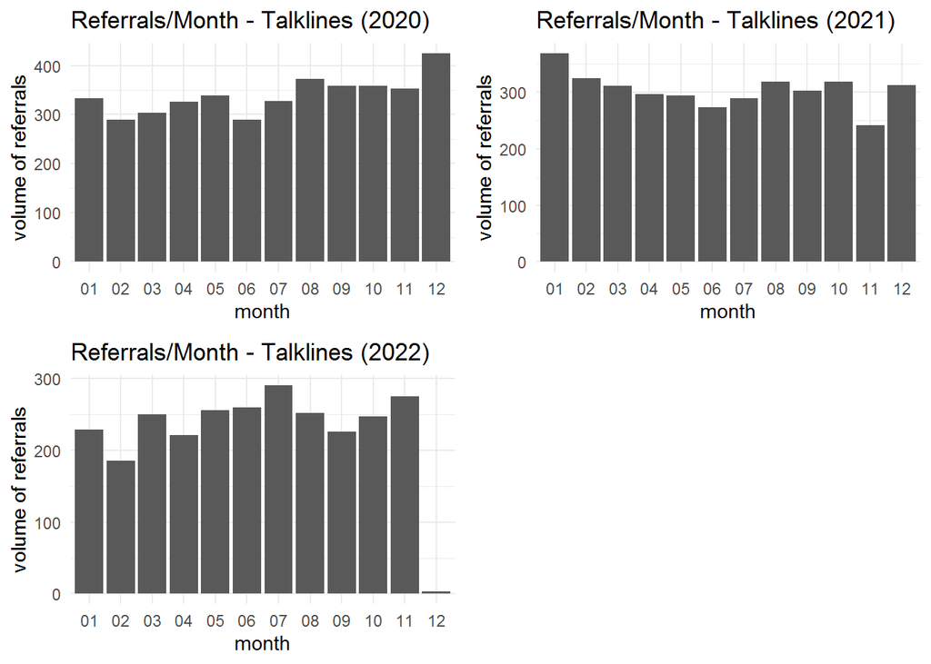

```r
#drawing the plot of the volume of referrals per month (talklines)

talklines_2020 <- talklines[grep("2020", talklines$Interaction_CreateStamp),]
talklines_2021 <- talklines[grep("2021", talklines$Interaction_CreateStamp),]
talklines_2022 <- talklines[grep("2022", talklines$Interaction_CreateStamp),]

table_19 <- as.data.frame(table(talklines_2020$month))

plot_19 <- ggplot(table_19, aes(x = Var1, y = Freq)) +
  geom_col()+
  labs(x = "month", y = "volume of referrals")+
  ggtitle('Referrals/Month - Talklines (2020)')+
  theme_minimal()

#plotting volume of referrals vs months

table_24 <- as.data.frame(table(talklines_2021$month))

plot_24 <- ggplot(table_24, aes(x = Var1, y = Freq)) +
  geom_col()+
  labs(x = "month", y = "volume of referrals")+
  ggtitle('Referrals/Month - Talklines (2021)')+
  theme_minimal()

#plotting volume of referrals vs months

table_25 <- as.data.frame(table(talklines_2022$month))

plot_25 <- ggplot(table_25, aes(x = Var1, y = Freq)) +
  geom_col()+
  labs(x = "month", y = "volume of referrals")+
  ggtitle('Referrals/Month - Talklines (2022)')+
  theme_minimal()

grid.arrange(plot_19, plot_24, plot_25, ncol=2)
```

- There does not seem to be a monthly trend for the number of talklines referrals.

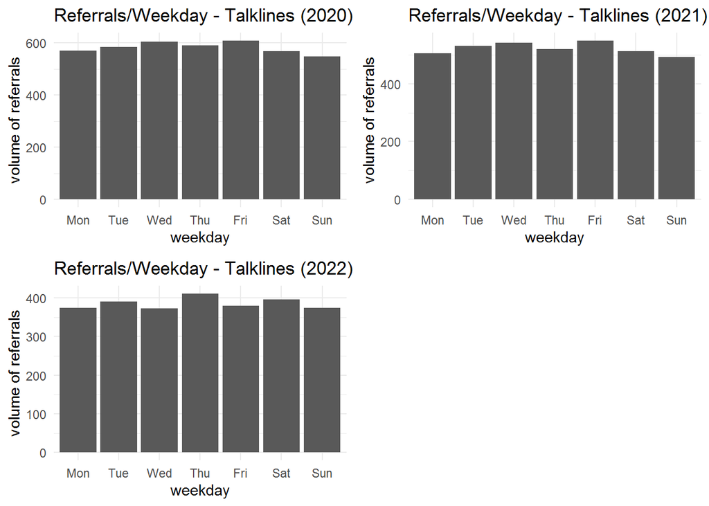

```r
#drawing the plot of the volume of calls per weekday

table_week <- as.data.frame(table(talklines_2020$day))

plot_1 <- ggplot(table_week, aes(x = Var1, y = Freq)) +
  geom_col()+
  labs(x = "weekday", y = "volume of referrals")+
  ggtitle('Referrals/Weekday - Talklines (2020)')+
  theme_minimal()


table_week <- as.data.frame(table(talklines_2021$day))

plot_2 <- ggplot(table_week, aes(x = Var1, y = Freq)) +
  geom_col()+
  labs(x = "weekday", y = "volume of referrals")+
  ggtitle('Referrals/Weekday - Talklines (2021)')+
  theme_minimal()


table_week <- as.data.frame(table(talklines_2022$day))

plot_3 <- ggplot(table_week, aes(x = Var1, y = Freq)) +
  geom_col()+
  labs(x = "weekday", y = "volume of referrals")+
  ggtitle('Referrals/Weekday - Talklines (2022)')+
  theme_minimal()

grid.arrange(plot_1, plot_2, plot_3, ncol=2)
```

- There does not seem to be a daily trend or pattern for the talkines referrals, apart from the fact that, just like the total number of calls seen previously, the volume of referrals tend to be lower on Sundays.

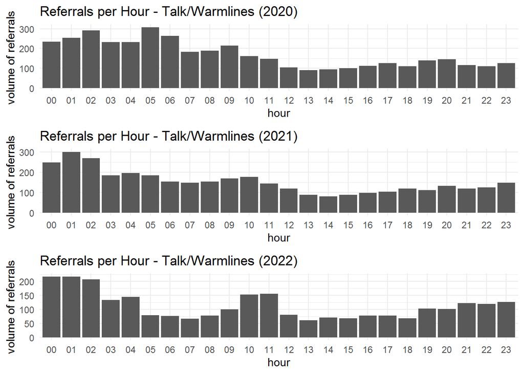

```r
#drawing the plot of the volume of referrals per hour

table_hour <- as.data.frame(table(talklines_2020$hour))

plot_1 <- ggplot(table_hour, aes(x = Var1, y = Freq)) +
  geom_col()+
  labs(x = "hour", y = "volume of referrals")+
  ggtitle('Referrals per Hour - Talk/Warmlines (2020)')+
  theme_minimal()


table_hour <- as.data.frame(table(talklines_2021$hour))

plot_2 <- ggplot(table_hour, aes(x = Var1, y = Freq)) +
  geom_col()+
  labs(x = "hour", y = "volume of referrals")+
  ggtitle('Referrals per Hour - Talk/Warmlines (2021)')+
  theme_minimal()

table_hour <- as.data.frame(table(talklines_2022$hour))

plot_3 <- ggplot(table_hour, aes(x = Var1, y = Freq)) +
  geom_col()+
  labs(x = "hour", y = "volume of referrals")+
  ggtitle('Referrals per Hour - Talk/Warmlines (2022)')+
  theme_minimal()

grid.arrange(plot_1, plot_2, plot_3)
```

- Interestingly, and unlike the total number of calls, the talklines calls tend to peak at night, around midnight, and the volume is less important during the late morning, early afternoon.

**Food Pantries**

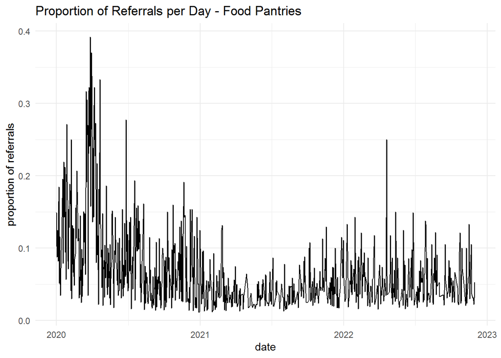

```r
#subsetting Food Pantries calls

food <- referrals[referrals$Taxonomy_Name=="'Food Pantries'",]

#calculating Food Pantries referral volume per day

table_15 <- as.data.frame(table(food$Interaction_CreateStamp))

#computing proportion vs total referrals

table_15 <- left_join(table_15, table_total, by='Var1')

table_15$Prop <- table_15$Freq.x/table_15$Freq.y

#drawing a time series plot of number of calls per day for the whole time-period

plot_15 <- ggplot(table_15, aes(x = as.Date(Var1), y = Prop)) +
  geom_line()+
  labs(x = "date", y = "proportion of referrals")+
  ggtitle('Proportion of Referrals per Day - Food Pantries')+
  theme_minimal()

plot_15
```

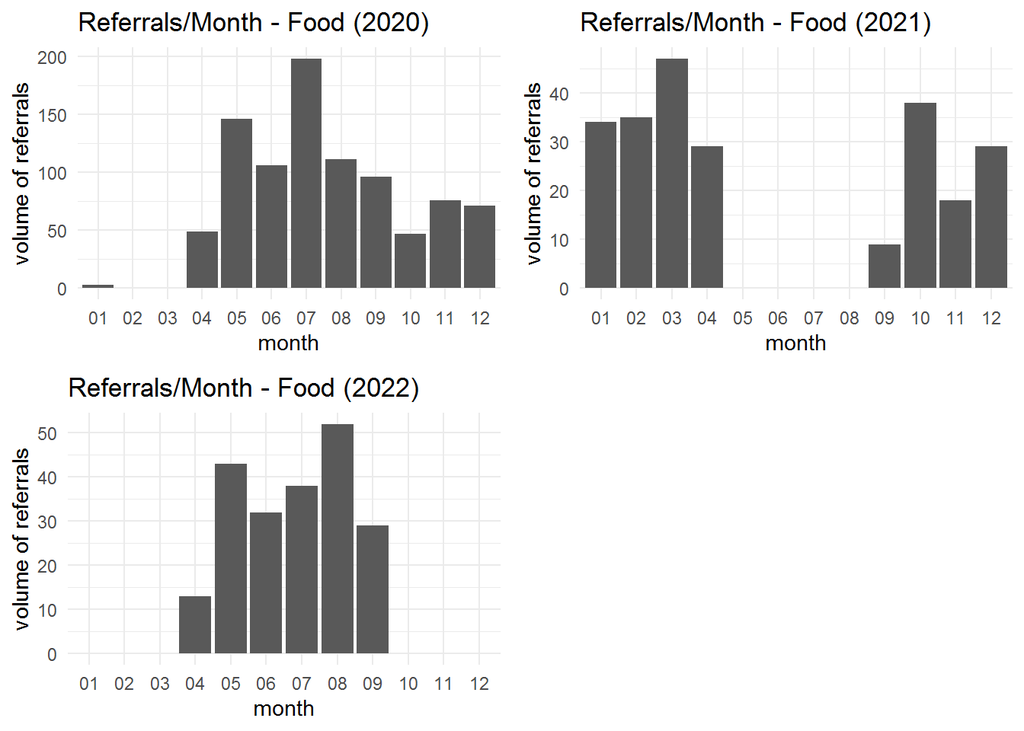

```r
#drawing the plot of the volume of referrals per month (food pantries)

food_2020 <- talklines[grep("2020", food$Interaction_CreateStamp),]
food_2021 <- talklines[grep("2021", food$Interaction_CreateStamp),]
food_2022 <- talklines[grep("2022", food$Interaction_CreateStamp),]

table_20 <- as.data.frame(table(food_2020$month))

plot_20 <- ggplot(table_20, aes(x = Var1, y = Freq)) +
  geom_col()+
  labs(x = "month", y = "volume of referrals")+
  ggtitle('Referrals/Month - Food (2020)')+
  theme_minimal()

table_26 <- as.data.frame(table(food_2021$month))

plot_26 <- ggplot(table_26, aes(x = Var1, y = Freq)) +
  geom_col()+
  labs(x = "month", y = "volume of referrals")+
  ggtitle('Referrals/Month - Food (2021)')+
  theme_minimal()

table_27 <- as.data.frame(table(food_2022$month))

plot_27 <- ggplot(table_27, aes(x = Var1, y = Freq)) +
  geom_col()+
  labs(x = "month", y = "volume of referrals")+
  ggtitle('Referrals/Month - Food (2022)')+
  theme_minimal()

grid.arrange(plot_20, plot_26, plot_27, ncol=2)
```

- There does not seem to be any monthly trend regarding the number of Food Pantries referrals for the past 3 years.

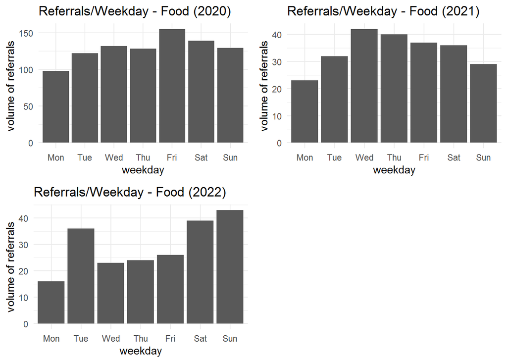

```r
#drawing the plot of the volume of calls per weekday

table_week <- as.data.frame(table(food_2020$day))

plot_1 <- ggplot(table_week, aes(x = Var1, y = Freq)) +
  geom_col()+
  labs(x = "weekday", y = "volume of referrals")+
  ggtitle('Referrals/Weekday - Food (2020)')+
  theme_minimal()

table_week <- as.data.frame(table(food_2021$day))

plot_2 <- ggplot(table_week, aes(x = Var1, y = Freq)) +
  geom_col()+
  labs(x = "weekday", y = "volume of referrals")+
  ggtitle('Referrals/Weekday - Food (2021)')+
  theme_minimal()

table_week <- as.data.frame(table(food_2022$day))

plot_3 <- ggplot(table_week, aes(x = Var1, y = Freq)) +
  geom_col()+
  labs(x = "weekday", y = "volume of referrals")+
  ggtitle('Referrals/Weekday - Food (2022)')+
  theme_minimal()

grid.arrange(plot_1, plot_2, plot_3, ncol=2)
```

- There does not seem to be any weekday trend regarding the number of Food Pantries referrals for the past 3 years

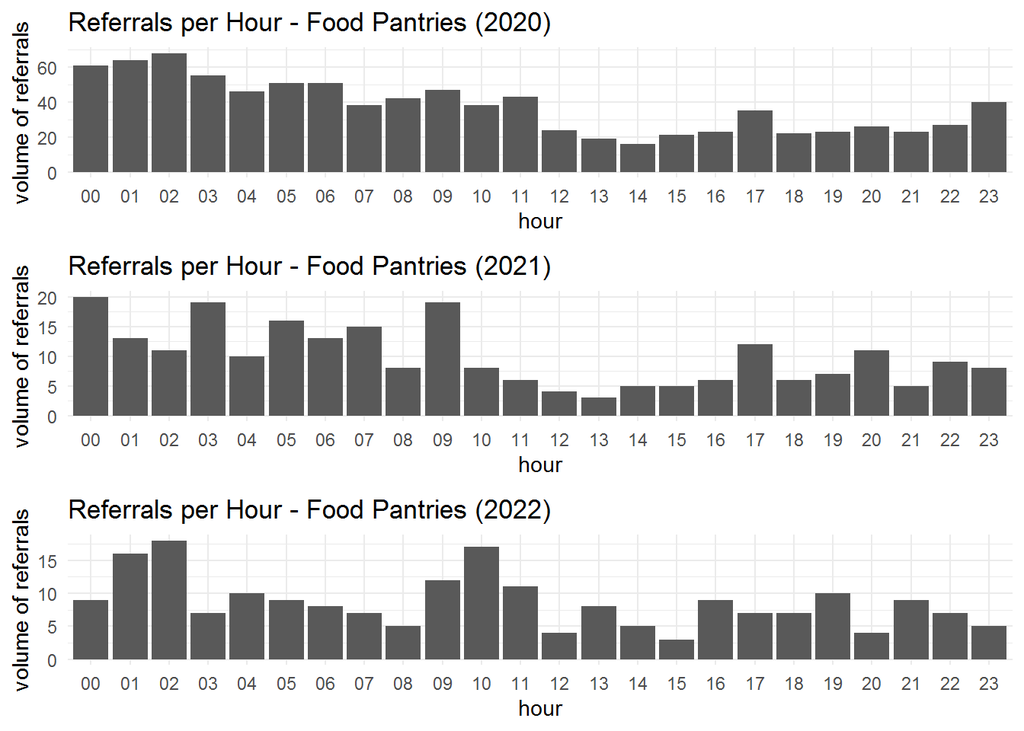

```r
#drawing the plot of the volume of referrals per hour

table_hour <- as.data.frame(table(food_2020$hour))

plot_1 <- ggplot(table_hour, aes(x = Var1, y = Freq)) +
  geom_col()+
  labs(x = "hour", y = "volume of referrals")+
  ggtitle('Referrals per Hour - Food Pantries (2020)')+
  theme_minimal()

table_hour <- as.data.frame(table(food_2021$hour))

plot_2 <- ggplot(table_hour, aes(x = Var1, y = Freq)) +
  geom_col()+
  labs(x = "hour", y = "volume of referrals")+
  ggtitle('Referrals per Hour - Food Pantries (2021)')+
  theme_minimal()

table_hour <- as.data.frame(table(food_2022$hour))

plot_3 <- ggplot(table_hour, aes(x = Var1, y = Freq)) +
  geom_col()+
  labs(x = "hour", y = "volume of referrals")+
  ggtitle('Referrals per Hour - Food Pantries (2022)')+
  theme_minimal()

grid.arrange(plot_1, plot_2, plot_3)
```

- The Food pantries referrals follow the same hourly trend as the talkines referrals, with a higher volume of referrals around midnight and less referrals around noon.
- The year 2022 contains less data, making inference less robust.

**Community Shelters**

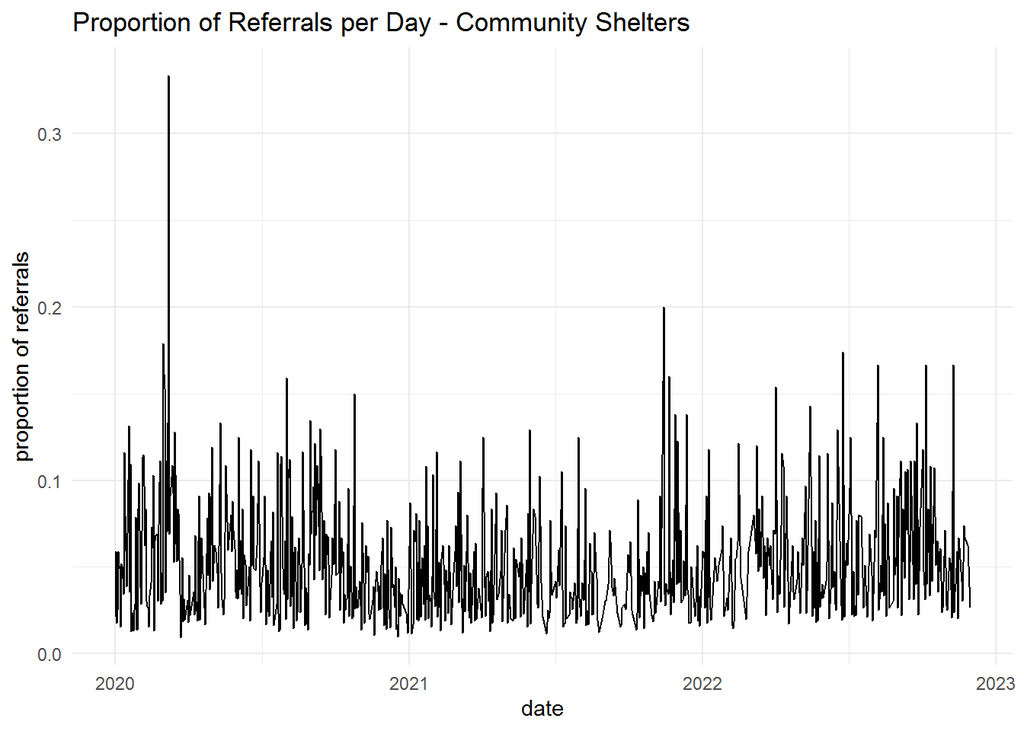

```r
#subsetting Community Shelters calls

shelter <- referrals[referrals$Taxonomy_Name=="'Community Shelters'",]

#calculating Community Shelters referral volume per day

table_16 <- as.data.frame(table(shelter$Interaction_CreateStamp))

#computing proportion vs total referrals

table_16 <- left_join(table_16, table_total, by='Var1')

table_16$Prop <- table_16$Freq.x/table_16$Freq.y

#drawing a time series plot of number of calls per day for the whole time-period

plot_16 <- ggplot(table_16, aes(x = as.Date(Var1), y = Prop)) +
  geom_line()+
  labs(x = "date", y = "proportion of referrals")+
  ggtitle('Proportion of Referrals per Day - Community Shelters ')+
  theme_minimal()

plot_16
```

- The proportion of shelter - related referrals seems constant during the past three years, between 0 and 10% of the total number of daily referrals most of the time.

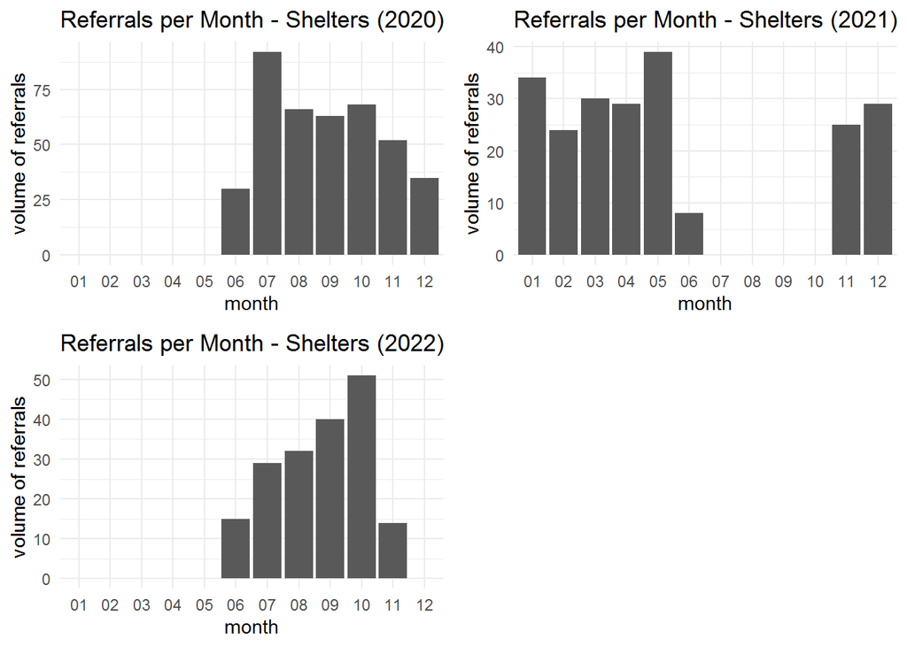

```r
#drawing the plot of the volume of referrals per month (shelters)

shelter_2020 <- talklines[grep("2020", shelter$Interaction_CreateStamp),]
shelter_2021 <- talklines[grep("2021", shelter$Interaction_CreateStamp),]
shelter_2022 <- talklines[grep("2022", shelter$Interaction_CreateStamp),]

table_21 <- as.data.frame(table(shelter_2020$month))

plot_21 <- ggplot(table_21, aes(x = Var1, y = Freq)) +
  geom_col()+
  labs(x = "month", y = "volume of referrals")+
  ggtitle('Referrals per Month - Shelters (2020)')+
  theme_minimal()

table_27 <- as.data.frame(table(shelter_2021$month))

plot_27 <- ggplot(table_27, aes(x = Var1, y = Freq)) +
  geom_col()+
  labs(x = "month", y = "volume of referrals")+
  ggtitle('Referrals per Month - Shelters (2021)')+
  theme_minimal()

table_28 <- as.data.frame(table(shelter_2022$month))

plot_28 <- ggplot(table_28, aes(x = Var1, y = Freq)) +
  geom_col()+
  labs(x = "month", y = "volume of referrals")+
  ggtitle('Referrals per Month - Shelters (2022)')+
  theme_minimal()

grid.arrange(plot_21, plot_27, plot_28, ncol=2)
```

- There does not seem to be any monthly trend regarding the number of shelters referrals for the past 3 years. The lack of data for this calls type prevents us from drawing significant data.

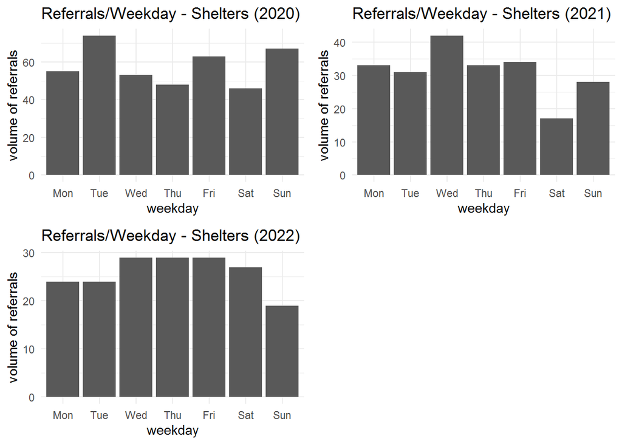

```r
#drawing the plot of the volume of calls per weekday

table_week <- as.data.frame(table(shelter_2020$day))

plot_1 <- ggplot(table_week, aes(x = Var1, y = Freq)) +
  geom_col()+
  labs(x = "weekday", y = "volume of referrals")+
  ggtitle('Referrals/Weekday - Shelters (2020)')+
  theme_minimal()

table_week <- as.data.frame(table(shelter_2021$day))

plot_2 <- ggplot(table_week, aes(x = Var1, y = Freq)) +
  geom_col()+
  labs(x = "weekday", y = "volume of referrals")+
  ggtitle('Referrals/Weekday - Shelters (2021)')+
  theme_minimal()

table_week <- as.data.frame(table(shelter_2022$day))

plot_3 <- ggplot(table_week, aes(x = Var1, y = Freq)) +
  geom_col()+
  labs(x = "weekday", y = "volume of referrals")+
  ggtitle('Referrals/Weekday - Shelters (2022)')+
  theme_minimal()

grid.arrange(plot_1, plot_2, plot_3, ncol=2)
```

- There does not seem to be any weekday trend regarding the number of shelters referrals for the past 3 years.

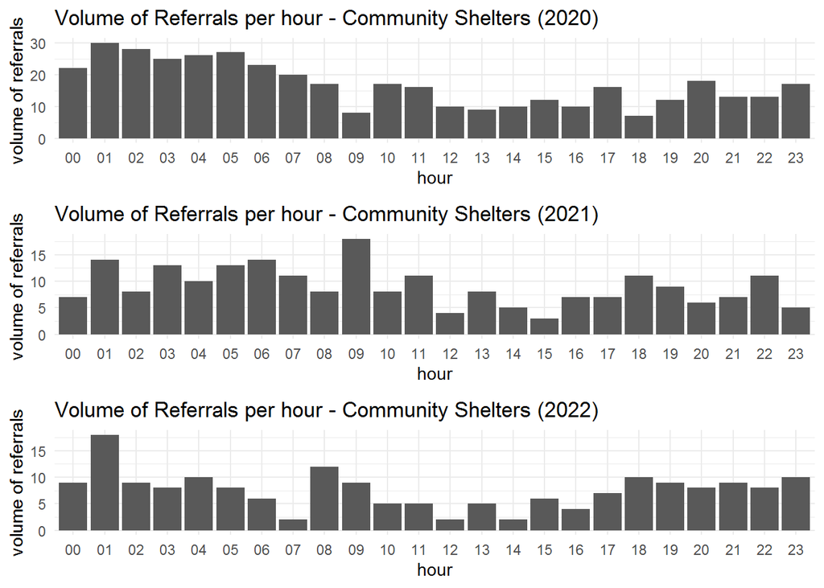

```r
#drawing the plot of the volume of referrals per hour

table_hour <- as.data.frame(table(shelter_2020$hour))

plot_1 <- ggplot(table_hour, aes(x = Var1, y = Freq)) +
  geom_col()+
  labs(x = "hour", y = "volume of referrals")+
  ggtitle('Volume of Referrals per hour - Community Shelters (2020)')+
  theme_minimal()

table_hour <- as.data.frame(table(shelter_2021$hour))

plot_2 <- ggplot(table_hour, aes(x = Var1, y = Freq)) +
  geom_col()+
  labs(x = "hour", y = "volume of referrals")+
  ggtitle('Volume of Referrals per hour - Community Shelters (2021)')+
  theme_minimal()

table_hour <- as.data.frame(table(shelter_2022$hour))

plot_3 <- ggplot(table_hour, aes(x = Var1, y = Freq)) +
  geom_col()+
  labs(x = "hour", y = "volume of referrals")+
  ggtitle('Volume of Referrals per hour - Community Shelters (2022)')+
  theme_minimal()

grid.arrange(plot_1, plot_2, plot_3)
```

- There does not seem to be any hourly trend regarding the number of Community Shelters referrals for the past 3 years.

**2.Calls types by area**

```r
#subsetting "clients" dataset - only WI

clients <- clients[clients$ClientAddressus_ClientAddressus_state=="WI",]

#merging "clients" dataset with "referrals" dataset

referrals <- left_join(referrals, clients[, c(1,7)], by="Client_Id")

#inspecting missing values

sum(is.na(referrals$ClientAddressus_ClientAddressus_county))
```

```
## [1] 3035
```

- There are 3,035 missing values in the “county” variable of the “clients” dataset. This variable is necessary to trace calls back to their location.

```r
#inspecting unique values in county variable

length(unique(referrals$ClientAddressus_ClientAddressus_county))
```

```
## [1] 46
```

```r
#inspecting unique values in county variable

unique(referrals$ClientAddressus_ClientAddressus_county)
```

```
##  [1] "La Crosse"   "Waukesha"    "Milwaukee"   NA            "Racine"
##  [6] "LA CROSSE"   "MILWAUKEE"   "JACKSON"     "RACINE"      "EAU CLAIRE"
## [11] "WAUKESHA"    "Chippewa"    "Washington"  "Sheboygan"   "Ozaukee"
## [16] "JEFFERSON"   "Walworth"    "Winnebago"   "MONROE"      "Kenosha"
## [21] "Outagamie"   "Langlade"    "Jefferson"   "WASHINGTON"  "Marathon"
## [26] "SAUK"        "Grant"       "Dane"        "Wood"        "Eau Claire"
## [31] "Rock"        "winnebago"   "WALWORTH"    "TREMPEALEAU" "KENOSHA"
## [36] "MARATHON"    "DODGE"       "SHEBOYGAN"   "Dodge"       "Brown"
## [41] "Crawford"    "Manitowoc"   "CHIPPEWA"    "Green"       "DANE"
## [46] "milwaukee"
```

- The variable contains duplicates and needs to be cleaned.

```r
#cleaning the county variable

referrals$ClientAddressus_ClientAddressus_county <-
  toupper(referrals$ClientAddressus_ClientAddressus_county)

#inspecting unique values in county variable

length(unique(referrals$ClientAddressus_ClientAddressus_county))
```

```
## [1] 30
```

```r
#inspecting unique values in county variable

unique(referrals$ClientAddressus_ClientAddressus_county)
```

```
##  [1] "LA CROSSE"   "WAUKESHA"    "MILWAUKEE"   NA            "RACINE"
##  [6] "JACKSON"     "EAU CLAIRE"  "CHIPPEWA"    "WASHINGTON"  "SHEBOYGAN"
## [11] "OZAUKEE"     "JEFFERSON"   "WALWORTH"    "WINNEBAGO"   "MONROE"
## [16] "KENOSHA"     "OUTAGAMIE"   "LANGLADE"    "MARATHON"    "SAUK"
## [21] "GRANT"       "DANE"        "WOOD"        "ROCK"        "TREMPEALEAU"
## [26] "DODGE"       "BROWN"       "CRAWFORD"    "MANITOWOC"   "GREEN"
```

```r
#printing number of referrals per county

table_county <- sort((table(referrals$ClientAddressus_ClientAddressus_county)),
                     decreasing = T)

kable(table_county)
```

| Var1 | Freq |
| --- | --- |
| MILWAUKEE | 33538 |
| LA CROSSE | 5647 |
| RACINE | 2243 |
| WAUKESHA | 2050 |
| EAU CLAIRE | 464 |
| CHIPPEWA | 127 |
| WASHINGTON | 77 |
| JEFFERSON | 57 |
| SHEBOYGAN | 52 |
| WALWORTH | 40 |
| KENOSHA | 39 |
| JACKSON | 34 |
| OUTAGAMIE | 29 |
| WINNEBAGO | 26 |
| DODGE | 25 |
| BROWN | 18 |
| MARATHON | 16 |
| DANE | 14 |
| OZAUKEE | 13 |
| WOOD | 12 |
| LANGLADE | 6 |
| GRANT | 5 |
| ROCK | 5 |
| MONROE | 4 |
| CRAWFORD | 3 |
| GREEN | 2 |
| MANITOWOC | 2 |
| SAUK | 2 |
| TREMPEALEAU | 2 |

- After computing the proportion table of the number of referrals per county, we can see that the referrals are not equally distributed.

```r
#fixing values in taxonomy_name

referrals$Taxonomy_Name <- str_replace(referrals$Taxonomy_Name,
                                       "'BD-1800.2000'",
                                       "'Food Pantries'")

#computing top 3 services per county

table_count <- referrals %>% count(ClientAddressus_ClientAddressus_county,
                    Taxonomy_Name)

table_count <- table_count[complete.cases(table_count), ]

table_count <- table_count %>%
  group_by(ClientAddressus_ClientAddressus_county) %>%
  top_n(3, n)

#renaming columns

colnames(table_count) <- c('County', 'Service', 'Volume')

#deleting counties with not enough data

table_count <- table_count[!grepl("brown", table_count$County,
                                  ignore.case = T),]

table_count <- table_count[!grepl("wood", table_count$County,
                                  ignore.case = T),]

table_count <- table_count[!grepl("dodge", table_count$County,
                                  ignore.case = T),]

table_count <- table_count[!grepl("dane", table_count$County,
                                  ignore.case = T),]

table_count <- table_count[!grepl("winnebago", table_count$County,
                                  ignore.case = T),]

table_count <- table_count[!grepl("washington", table_count$County,
                                  ignore.case = T),]

table_count <- table_count[!grepl("crawford", table_count$County,
                                  ignore.case = T),]

table_count <- table_count[!grepl("WALWORTH", table_count$County,
                                  ignore.case = T),]

table_count <- table_count[!grepl("TREMPEALEAU", table_count$County,
                                  ignore.case = T),]

table_count <- table_count[!grepl("SHEBOYGAN", table_count$County,
                                  ignore.case = T),]

table_count <- table_count[!grepl("sauk", table_count$County,
                                  ignore.case = T),]

table_count <- table_count[!grepl("rock", table_count$County,
                                  ignore.case = T),]

table_count <- table_count[!grepl("ozaukee", table_count$County,
                                  ignore.case = T),]

table_count <- table_count[!grepl("outagamie", table_count$County,
                                  ignore.case = T),]

table_count <- table_count[!grepl("monroe", table_count$County,
                                  ignore.case = T),]

table_count <- table_count[!grepl("marathon", table_count$County,
                                  ignore.case = T),]

table_count <- table_count[!grepl("MANITOWOC", table_count$County,
                                  ignore.case = T),]

table_count <- table_count[!grepl("langlade", table_count$County,
                                  ignore.case = T),]

table_count <- table_count[!grepl("kenosha", table_count$County,
                                  ignore.case = T),]

table_count <- table_count[!grepl("jefferson", table_count$County,
                                  ignore.case = T),]

table_count <- table_count[!grepl("jackson", table_count$County,
                                  ignore.case = T),]

table_count <- table_count[!grepl("green", table_count$County,
                                  ignore.case = T),]

table_count <- table_count[!grepl("grant", table_count$County,
                                  ignore.case = T),]

#sorting the dataframe

table_count <-
  table_count[order(table_count$County,
                    table_count$Volume, decreasing = T),]

kable(table_count)
```

| County | Service | Volume |
| --- | --- | --- |
| WAUKESHA | ‘Talklines/Warmlines’ | 1167 |
| WAUKESHA | ‘General Crisis Intervention Hotlines’ | 64 |
| WAUKESHA | ‘Community Shelters’ | 33 |
| WAUKESHA | ‘IMPACT’ | 33 |
| RACINE | ‘Food Pantries’ | 564 |
| RACINE | ‘211 Systems’ | 45 |
| RACINE | ‘Rent Payment Assistance’ | 44 |
| MILWAUKEE | ‘Food Pantries’ | 2517 |
| MILWAUKEE | ‘Talklines/Warmlines’ | 1877 |
| MILWAUKEE | ‘Community Shelters’ | 1652 |
| LA CROSSE | ‘Talklines/Warmlines’ | 4226 |
| LA CROSSE | ‘Directory Assistance’ | 136 |
| LA CROSSE | ‘General Crisis Intervention Hotlines’ | 61 |
| EAU CLAIRE | ‘Talklines/Warmlines’ | 414 |
| EAU CLAIRE | ‘General Crisis Intervention Hotlines’ | 3 |
| EAU CLAIRE | ‘GREAT RIVERS 2-1-1’ | 3 |
| CHIPPEWA | ‘Talklines/Warmlines’ | 50 |
| CHIPPEWA | ‘Hospitals’ | 8 |
| CHIPPEWA | ‘Medical Information Services’ | 5 |
| CHIPPEWA | ‘Substance Use Disorder Peer Recovery Coach Services’ | 5 |

- Only 6 counties have been kept in the table above, the other counties did not make the cut because of a lack of data making statistic non-significant.
- Most requested services vary per county. For example, the 211 line receives mainly food-based calls from Racine, whereas propose more often talklines referrals to their clients based in Waukesha, La Crosse or Eau Claire.